# Taller 6

Métodos Computacionales para Políticas Públicas - URosario

**Entrega: viernes 28-sep-2018 11:59 PM**

**[Juan Camilo Perdomo]**  
[juan.perdomor@urosario.edu.co]

## Instrucciones:

- Guarde una copia de este *Jupyter Notebook* en su computador, idealmente en una carpeta destinada al material del curso.
- Modifique el nombre del archivo del *notebook*, agregando al final un guión inferior y su nombre y apellido, separados estos últimos por otro guión inferior. Por ejemplo, mi *notebook* se llamaría: mcpp_taller6_santiago_matallana
- Marque el *notebook* con su nombre y e-mail en el bloque verde arriba. Reemplace el texto "[Su nombre acá]" con su nombre y apellido. Similar para su e-mail.
- Desarrolle la totalidad del taller sobre este *notebook*, insertando las celdas que sea necesario debajo de cada pregunta. Haga buen uso de las celdas para código y de las celdas tipo *markdown* según el caso.
- Recuerde salvar periódicamente sus avances.
- Cuando termine el taller:
  1. Descárguelo en PDF. Si tiene algún problema con la conversión, descárguelo en HTML.
  2. Suba todos los archivos a su repositorio en GitHub, en una carpeta destinada exclusivamente para este taller, antes de la fecha y hora límites.

(Todos los ejercicios tienen el mismo valor.)

### Resuelva la parte 1 de [este documento](http://www.math.pitt.edu/~sussmanm/3040Summer14/exercisesII.pdf).

```python
import numpy as np
import scipy.linalg as la
import matplotlib.pyplot as plt
```

#### 1. Choose a value and set the variable x to that value.

```python
x = [[2,4,6], [8,10,12], [12,16,18]]
```

#### 2. What is command to compute the square of x? Its cube?

```python
x2 = np.array(x)
print(x2**2)
```

```
[[  4  16  36]
 [ 64 100 144]
 [144 256 324]]
```

```python
x3 = np.array(x)
print(x2**3)
```

```
[[   8   64  216]
 [ 512 1000 1728]
 [1728 4096 5832]]
```

### Resuelva los ejercicios de las secciones 4.1, 5.1, 6.1, 7.4 y 8.5 de [este documento](http://www.python-academy.com/download/pycon2012/matplotlib_handout.pdf).

### 4.1

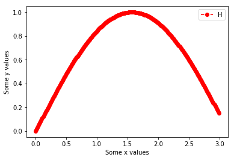

```python
import matplotlib.pyplot as plt
xs = np.arange(0,3,0.01)
plt.plot(xs, np.sin(xs),'r--o', color="red")
plt.xlabel("Some x values")
plt.ylabel("Some y values")
plt.legend("Hola")
```

### 5.1

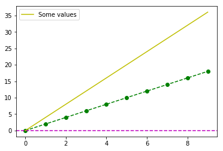

```python
ys=np.arange(0,20,2)
plt.plot(ys,'r--o', color="green")
plt.axhline(0, color="m", linestyle="--")
plt.plot(ys*2, label = "Some values", color="y")
plt.legend();
```

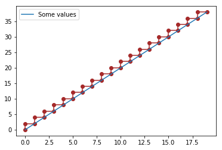

```python
ys=np.arange(0,40,2)
plt.step(ys,'r--o', color="brown")
plt.plot(ys, label = "Some values")
plt.legend();
```

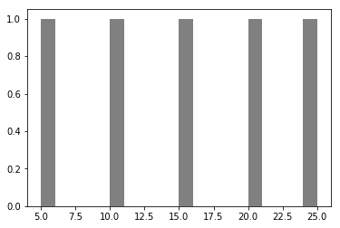

```python
values=(5, 10, 15, 20, 25)
plt.hist(values, bins=20, color="grey")
labels = ["5", "10", "15", "20", "25"]
```

### 6.1

```
Text(17,35,'Qué más')
```

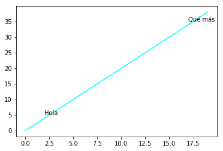

```python
ys=np.arange(0,40,2)
plt.plot(ys, color="cyan", label = "Some values")
plt.annotate('Hola', xy = (2, 1), xytext=(2,5))
plt.annotate('Qué más', xy = (8, 8), xytext=(17,35))
```

### 7.4

[output not shown]

[figure not shown]

```python
dates = ['03/11/1991','04/11/1992','27/04/2002']
x=np.arange(365)
y = range(len(x))
import matplotlib.dates as dates
```

```python
dates = pd.to_datetime([datetime(2015, 7, 3), '4th of July, 2015','2015-Jul-6', '07-07-2015', '20150708'])
%matplotlib inline
import matplotlib.pyplot as plt
import seaborn; seaborn.set()
goog.plot();
```

[output not shown]

```python
import numpy as np
date = np.array('2018-09-28', dtype=np.datetime64)
date
date + np.arange(3)
```

```
array(['2018-09-28', '2018-09-29', '2018-09-30'], dtype='datetime64[D]')
```

```python
import numpy as np
import pandas as pd
from bokeh.charts import Bar, show, output_notebook
output_notebook()

s = pd.date_range('2016-01-01', periods=100, freq='D')
df = pd.DataFrame(np.random.randint(0,5, size=(100,2)), columns=['A','B'], index=s)

data = df.resample('W', how='sum')
data.index.name='DATE'
data = data.reset_index()
show(Bar(data, label='DATE', values='A'));
data.DATE = data.DATE.apply(lambda x: str(x).split(' 00:00:00')[0])
```

[output not shown]